# OIS4 Chap 7, Inference for numerical data

2008-351-351m-451-w11b-p2-OIS4Ch7-InferenceForNumericalData

## Getting Started

### Load packages

In this lab, we will explore and visualize the data

- using the **tidyverse** suite of packages,
- and perform statistical inference using **infer**.

The data can be found in the companion package

- for OpenIntro resources, **openintro**.

Let’s load the packages.

```r
library(tidyverse)
library(openintro)
library(infer)
```

### The data

Every two years, the Centers for Disease Control and Prevention

- conduct the Youth Risk Behavior Surveillance System (YRBSS) survey,
- where it takes data from high schoolers (9th through 12th grade),
- to analyze health patterns.

You will work with a selected group of variables

- from a random sample of observations
- during one of the years the YRBSS was conducted.

Load the `yrbss` data set into your workspace.

```r
data(yrbss)
```

There are observations on 13 different variables,

- some categorical and some numerical.

The meaning of each variable can be found

- by bringing up the help file:

```r
?yrbss
```

1. What are the cases in this data set?
- How many cases are there in our sample?

Remember that you can answer this question

- by viewing the data in the data viewer
- or by using the following command:

```r
glimpse(yrbss)
```

```
## Rows: 13,583
## Columns: 13
## $ age                      <int> 14, 14, 15, 15, 15, 15, 15, 14, 15, 15, 15, 1…
## $ gender                   <chr> "female", "female", "female", "female", "fema…
## $ grade                    <chr> "9", "9", "9", "9", "9", "9", "9", "9", "9", …
## $ hispanic                 <chr> "not", "not", "hispanic", "not", "not", "not"…
## $ race                     <chr> "Black or African American", "Black or Africa…
## $ height                   <dbl> NA, NA, 1.73, 1.60, 1.50, 1.57, 1.65, 1.88, 1…
## $ weight                   <dbl> NA, NA, 84.37, 55.79, 46.72, 67.13, 131.54, 7…
## $ helmet_12m               <chr> "never", "never", "never", "never", "did not …
## $ text_while_driving_30d   <chr> "0", NA, "30", "0", "did not drive", "did not…
## $ physically_active_7d     <int> 4, 2, 7, 0, 2, 1, 4, 4, 5, 0, 0, 0, 4, 7, 7, …
## $ hours_tv_per_school_day  <chr> "5+", "5+", "5+", "2", "3", "5+", "5+", "5+",…
## $ strength_training_7d     <int> 0, 0, 0, 0, 1, 0, 2, 0, 3, 0, 3, 0, 0, 7, 7, …
## $ school_night_hours_sleep <chr> "8", "6", "<5", "6", "9", "8", "9", "6", "<5"…
```

## Exploratory data analysis

You will first start with analyzing

- the weight of the participants in kilograms: `weight`.

Using visualization and summary statistics,

- describe the distribution of weights.

The `summary` function can be useful.

```r
summary(yrbss$weight)
```

```
##    Min. 1st Qu.  Median    Mean 3rd Qu.    Max.    NA's
##   29.94   56.25   64.41   67.91   76.20  180.99    1004
```

1. How many observations are we missing weights from?

Next, consider the possible relationship between

- a high schooler’s weight
  - and their physical activity.

Plotting the data is a useful first step

- because it helps us
  - quickly visualize trends,
  - identify strong associations, and
  - develop research questions.

First, let’s create a new variable `physical_3plus`,

- which will be coded as either “yes”
  - if they are physically active for at least 3 days a week,
- and “no” if not.

```r
yrbss <- yrbss %>%
  mutate(physical_3plus = ifelse(yrbss$physically_active_7d > 2, "yes", "no"))
```

1. Make a side-by-side boxplot
- of `physical_3plus`
- and `weight`.

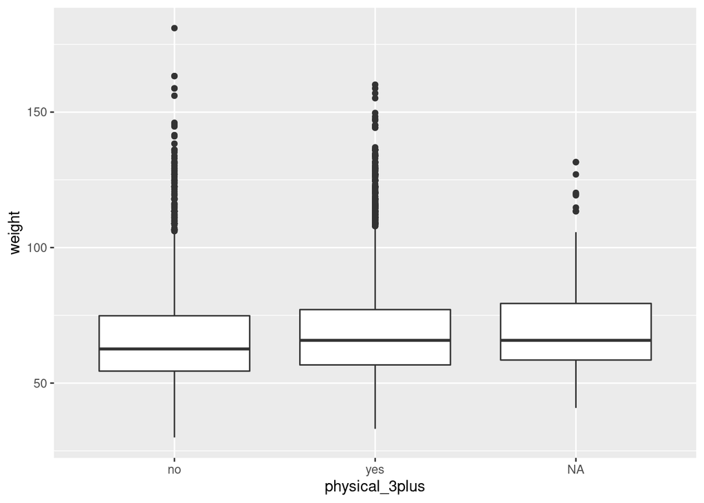

```r
ggplot(yrbss, aes(x = physical_3plus, y = weight)) + geom_boxplot()
```

Is there a relationship between these two variables?

What did you expect and why?

The box plots show

- how the medians of the two distributions compare,

But we can also compare

- the means of the distributions using the following
  - to first group the data by the `physical_3plus` variable,
  - and then calculate the mean `weight` in these groups
    - using the `mean` function
  - while ignoring missing values
    - by setting the `na.rm` argument to `TRUE`.

```r
yrbss %>%
  group_by(physical_3plus) %>%
  summarise(mean_weight = mean(weight, na.rm = TRUE))
```

```
## # A tibble: 3 × 2
##   physical_3plus mean_weight
##   <chr>                <dbl>
## 1 no                    66.7
## 2 yes                   68.4
## 3 <NA>                  69.9
```

There is an observed difference,

- but is this difference statistically significant?

In order to answer this question

- we will conduct a hypothesis test.

## Inference

1. Are all conditions necessary for inference satisfied?

Comment on each.

- You can compute the group sizes
  - with the `summarize` command above
  - by defining a new variable with the definition `n()`.
1. Write the hypotheses
- for testing if the average weights are different
  - for those who exercise at least times a week
- and those who don’t.

Next, we will introduce a new function, `hypothesize`,

- that falls into the `infer` workflow.

You will use this method

- for conducting hypothesis tests.

But first, we need to initialize the test,

- which we will save as `obs_diff`.

```r
obs_diff <- yrbss %>%
  specify(weight ~ physical_3plus) %>%
  calculate(stat = "diff in means", order = c("yes", "no"))
obs_diff
```

```
## Response: weight (numeric)
## Explanatory: physical_3plus (factor)
## # A tibble: 1 × 1
##    stat
##   <dbl>
## 1  1.77
```

Notice how you can use the functions

- `specify` and `calculate` again
  - like you did for calculating confidence intervals.

Here, though, the statistic you are searching for

- is the difference in means,
  - with the order being `yes - no != 0`.

After you have initialized the test,

- you need to simulate the test on the null distribution,
- which we will save as `null`.

```r
null_dist <- yrbss %>%
  specify(weight ~ physical_3plus) %>%
  hypothesize(null = "independence") %>%
  generate(reps = 1000, type = "permute") %>%
  calculate(stat = "diff in means", order = c("yes", "no"))
```

Here, `hypothesize` is used

- to set the null hypothesis as a test for independence.

In one sample cases,

- the `null` argument can be set to “point”
  - to test a hypothesis relative to a point estimate.

Also, note that the `type` argument within `generate`

- is set to `permute`, which is the argument
- when generating a null distribution for a hypothesis test.

We can visualize this null distribution with the following code:

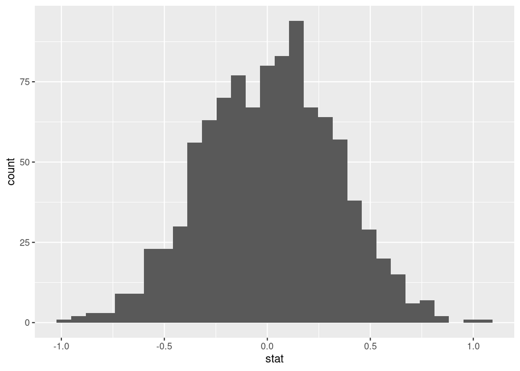

```r
ggplot(data = null_dist, aes(x = stat)) +
  geom_histogram()
```

1. How many of these `null` permutations
- have a difference of at least `obs_stat`?

Now that the test

- is initialized
  - and the null distribution formed,
- you can calculate the p-value for your hypothesis test
  - using the function `get_p_value`.

```r
null_dist %>%
  get_p_value(obs_stat = obs_diff, direction = "two_sided")
```

```
## # A tibble: 1 × 1
##   p_value
##     <dbl>
## 1       0
```

This the standard workflow for performing hypothesis tests.

1. Construct and record a confidence interval
- for the difference between the weights of
  - those who exercise at least three times a week
  - and those who don’t,
- and interpret this interval in context of the data.

## More Practice

1. Calculate a 95% confidence interval
- for the average height in meters (`height`)
- and interpret it in context.
1. Calculate a new confidence interval
- for the same parameter at the 90% confidence level.
- Comment on the width of this interval
  - versus the one obtained in the previous exercise.
1. Conduct a hypothesis test
- evaluating whether the average height is different
  - for those who exercise at least three times a week
  - and those who don’t.
1. Now, a non-inference task:
- Determine the number of different options there are in the dataset
  - for the `hours_tv_per_school_day` there are.
1. Come up with a research question
- evaluating the relationship between height or weight and sleep.
- Formulate the question in a way that it can be answered
  - using a hypothesis test and/or a confidence interval.
- Report the statistical results,
  - and also provide an explanation in plain language.
- Be sure to check all assumptions,
  - state your $\alpha$ level,
  - and conclude in context.

This work is licensed under a [Creative Commons Attribution-ShareAlike 4.0 International License](http://creativecommons.org/licenses/by-sa/4.0/).